# Practical Machine Learning Course Project

Tung Hoang

### Summary

In this project, we are going to use the recorded activity data given in ‘pml-training.csv’ file to build a model predicting 5 different ways of performing barbell lifts. Details about the original data set can be found on this website: http://web.archive.org/web/20161224072740/http:/groupware.les.inf.puc-rio.br/har

In this multi-class classification problem, Support Vector Machines with Radial Kernel algorithm (caret package) was used to predict the excercise data. The data was divided into train, validate and test sets. The final model has very high out-of-the-bag accuracy rate (0.99)

### Data Cleaning

First we load the data and get some understanding of its structure.

```r
pml <- read.csv('pml-training.csv', na.strings = c('','NA'))
dim(pml)
```

```
## [1] 19622   160
```

The initial impression is that the data has a large number of features (160). The predicted value is the last column ‘classe’. However, not all variables are relevant, for example, index, user name, time stamp etc. Also, we will need to perform some feature selection technique to select the variables for the prediction model.

Some variables contains blank or null values so we first eliminate these columns and also the first 7 columns. Now the dataset includes the predicted value and 52 numerical variables

```r
pml <- pml[,c(8:ncol(pml))]
pml <- pml[,colSums(is.na(pml))==0]
dim(pml)
```

```
## [1] 19622    53
```

### Train, Validate & Test Set

As the dataset is quiet large, using k-fold validation will take a lot of time to train a model. We divide the dataset into train, validate and test set with the proportion of 0.7, 0.15 and 0.15 respectively.

```r
set.seed(1991)
train_validate_test <- sample(1:3, nrow(pml), replace = TRUE, prob = c(0.7,0.15,0.15))

train <- pml[train_validate_test==1,]
validate <- pml[train_validate_test==2,]
test <- pml[train_validate_test==3,]
```

### Support Vector Machines with Radial Basis Function Kernel

I chose SVM for this prediction model because it is said to be effective with high dimensional data and also memory efficient, i.e. faster to train with my computer than Random Forest/ensemble methods.

We will use the SVM with Radial Kernel training function provided in the ‘caret’ pakage.

Note that the code below creates the option to do parallel processing with caret, improving the computing time.

```r
library(doParallel)
cores_2_use <- detectCores()
cl <- makeCluster(cores_2_use, useXDR = F)
clusterSetRNGStream(cl, 9956)
registerDoParallel(cl, cores_2_use)
```

First, we run a simple SVM model on the training set with the default options without tuning any parameter and no resampling. In this case, the default kernel type is radial, cost = 1 and gamma = 1.

```r
library(caret)
# Train the 1st model
svm.model1 <- train(classe~., data = train,
                    method = 'svmRadial',
                    trControl = trainControl(method = 'none'),
                    allowParallel = TRUE)

# Predict the validate set
svm.validate.pred1 <- predict(svm.model1, newdata=validate)

# Model performance
confusion.matrix1 <- confusionMatrix(data = svm.validate.pred1, reference = validate$classe)
confusion.matrix1
```

```
## Confusion Matrix and Statistics
##
##           Reference
## Prediction   A   B   C   D   E
##          A 831  73  14   6   6
##          B   4 451  34  10  21
##          C  10  50 460  59  37
##          D  10   5  23 398  27
##          E   1  11   1   3 427
##
## Overall Statistics
##
##                Accuracy : 0.8637
##                  95% CI : (0.8509, 0.8759)
##     No Information Rate : 0.288
##     P-Value [Acc > NIR] : < 2.2e-16
##
##                   Kappa : 0.8269
##  Mcnemar's Test P-Value : < 2.2e-16
##
## Statistics by Class:
##
##                      Class: A Class: B Class: C Class: D Class: E
## Sensitivity            0.9708   0.7644   0.8647   0.8361   0.8243
## Specificity            0.9532   0.9710   0.9361   0.9740   0.9935
## Pos Pred Value         0.8935   0.8673   0.7468   0.8596   0.9639
## Neg Pred Value         0.9878   0.9433   0.9694   0.9689   0.9640
## Prevalence             0.2880   0.1985   0.1790   0.1602   0.1743
## Detection Rate         0.2796   0.1517   0.1548   0.1339   0.1437
## Detection Prevalence   0.3129   0.1750   0.2073   0.1558   0.1491
## Balanced Accuracy      0.9620   0.8677   0.9004   0.9050   0.9089
```

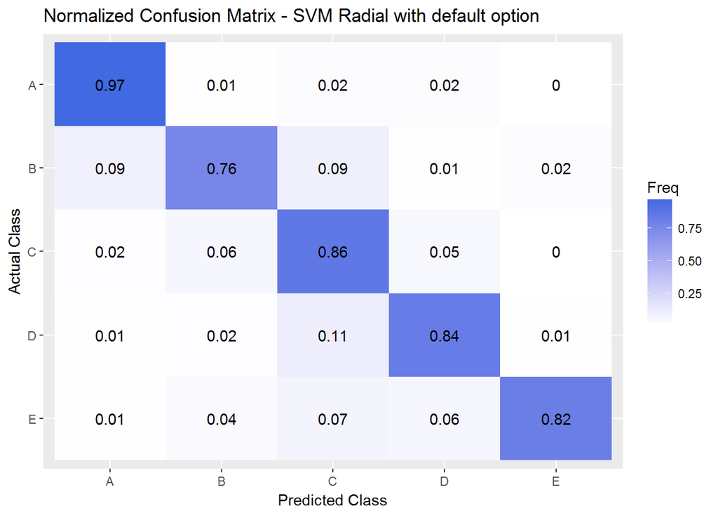

```r
library(ggplot2)

# Calculate the frequency from the confusion matrix
confusion.matrix.pct1 <- as.data.frame(confusion.matrix1$table/colSums(confusion.matrix1$table))

# Plot the heat map
ggplot(confusion.matrix.pct1, aes(Prediction, forcats::fct_rev(Reference), fill=Freq)) +
  geom_tile() +
  scale_fill_gradient(low = 'white', high = 'royalblue') +
  geom_text(aes(label=round(Freq, digits = 2))) +
  labs(title = 'Normalized Confusion Matrix - SVM Radial with default option',
       x = 'Predicted Class',
       y = 'Actual Class')
```

### Model Tuning

Even though the first simple run of SVM model with radial kernel has quite a good result, we can try to tune the SVM algorithm to see if we can effectively improves the model performance. To be simple, we will choose the radial kernel and the other two parameters that we will tune the SVM include its cost and sigma. - Cost is the cost of constraints violation, i.e. the ‘C’ constant of the regulation term om the Lagrange formulation. - Sigma is the parametter needed for the radial kernel.

Detailed mathematical explanations: https://en.wikipedia.org/wiki/Support_vector_machine

The train function from the package ‘caret’ will search for the best cost and sigma parameters provided in the tuneGrid. We will limit the range of sigma within (0.01, 0.1) and Cost within (0.1, 1 , 10)

```r
svm.grid <- expand.grid(sigma = 10^(-2:-1),C=10^(-1:1))

set.seed(1991)
# The train control method is 5-fold cross validation
fitControl <- trainControl(method = 'cv', number = 5)

# Fit the model and searching for the best parameters
svm.model2 <- train(classe~., data = train, method = 'svmRadial',
                    trControl = fitControl,
                    tuneGrid = svm.grid,
                    allowParallel = TRUE)
svm.model2
```

```
## Support Vector Machines with Radial Basis Function Kernel
##
## 13711 samples
##    52 predictor
##     5 classes: 'A', 'B', 'C', 'D', 'E'
##
## No pre-processing
## Resampling: Cross-Validated (5 fold)
## Summary of sample sizes: 10969, 10970, 10969, 10967, 10969
## Resampling results across tuning parameters:
##
##   sigma  C     Accuracy   Kappa
##   0.01    0.1  0.7305828  0.6577151
##   0.01    1.0  0.8996451  0.8728731
##   0.01   10.0  0.9688574  0.9606032
##   0.10    0.1  0.8635436  0.8272746
##   0.10    1.0  0.9734522  0.9664319
##   0.10   10.0  0.9910292  0.9886611
##
## Accuracy was used to select the optimal model using the largest value.
## The final values used for the model were sigma = 0.1 and C = 10.
```

### Final model

The tuning process identify sigma = 0.1 and C = 10 as the optimal parameters for SVM with radial kernal. We will fit the model with these parameters with the remaining test set and estimate the out of the bag error rates.

```r
svm.model3 <- train(classe~., data = train, method = 'svmRadial',
                    trControl = trainControl(method = 'none'),
                    tuneGrid = data.frame(sigma = 0.1, C = 10)
                    )

svm.test.pred <- predict(svm.model3, newdata = test)

confusion.matrix3 <- confusionMatrix(data = svm.test.pred, reference = test$classe)
confusion.matrix3
```

```
## Confusion Matrix and Statistics
##
##           Reference
## Prediction   A   B   C   D   E
##          A 862   0   0   0   0
##          B   1 550   0   0   0
##          C   0   0 494   7   0
##          D   0   0   5 453   0
##          E   1   0   1   3 562
##
## Overall Statistics
##
##                Accuracy : 0.9939
##                  95% CI : (0.9903, 0.9964)
##     No Information Rate : 0.294
##     P-Value [Acc > NIR] : < 2.2e-16
##
##                   Kappa : 0.9922
##  Mcnemar's Test P-Value : NA
##
## Statistics by Class:
##
##                      Class: A Class: B Class: C Class: D Class: E
## Sensitivity            0.9977   1.0000   0.9880   0.9784   1.0000
## Specificity            1.0000   0.9996   0.9971   0.9980   0.9979
## Pos Pred Value         1.0000   0.9982   0.9860   0.9891   0.9912
## Neg Pred Value         0.9990   1.0000   0.9975   0.9960   1.0000
## Prevalence             0.2940   0.1871   0.1701   0.1575   0.1912
## Detection Rate         0.2933   0.1871   0.1681   0.1541   0.1912
## Detection Prevalence   0.2933   0.1875   0.1705   0.1558   0.1929
## Balanced Accuracy      0.9988   0.9998   0.9926   0.9882   0.9989
```

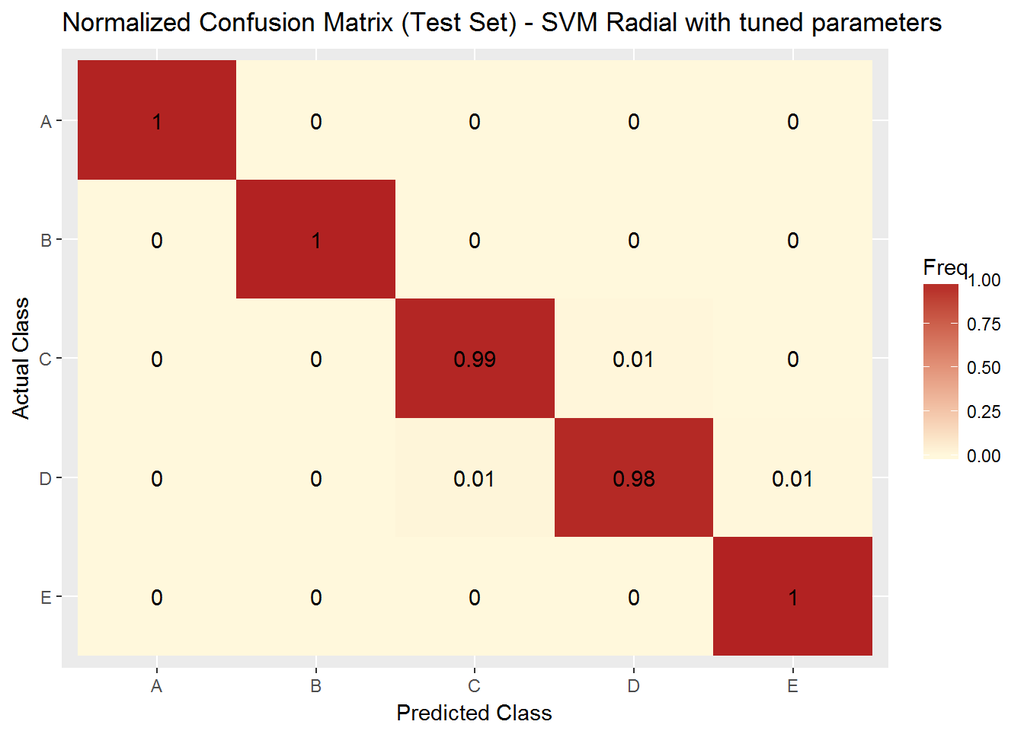

```r
# Calculate the frequency from the confusion matrix
confusion.matrix.pct3 <- as.data.frame(confusion.matrix3$table/colSums(confusion.matrix3$table))

# Plot the heat map
ggplot(confusion.matrix.pct3, aes(Prediction, forcats::fct_rev(Reference), fill=Freq)) +
  geom_tile() +
  scale_fill_gradient(low = 'cornsilk', high = 'firebrick') +
  geom_text(aes(label=round(Freq, digits = 2))) +
  labs(title = 'Normalized Confusion Matrix (Test Set) - SVM Radial with tuned parameters',
       x = 'Predicted Class',
       y = 'Actual Class')
```

### 2nd part of the project - Predicting the test set

The final part of the project is fairly simple. We use the final model on the provided test data to predict new 20 cases and answer the quiz. The result is 100% correct.

```r
pml.test <- read.csv('pml-testing.csv')

pml.test.pred <- predict(svm.model3, newdata = pml.test)

pml.test.pred
```

```
##  [1] B A B A A E D B A A B C B A E E A B B B
## Levels: A B C D E
```